# Q 1

```r
library(ggplot2)
library(GGally)
library(broom)
library(tidyr)
```

```r
df = read.table("rustdrugs2016.txt", header = T)
df$DM = 100000*df$Deaths/df$Population
df$IM = df$Income/1000
df$TM = 100*df$Trump
dfw = df[, c("DM","IM","TM","PctWhite")]
head(dfw)
```

| DM | IM | TM | PctWhite |
| --- | --- | --- | --- |
| 15.01998 | 45.073 | 71.55178 | 93.7 |
| 11.51526 | 45.808 | 37.26064 | 74.5 |
| 30.02192 | 45.145 | 68.72632 | 96.5 |
| 21.71616 | 54.548 | 21.41932 | 65.9 |
| 16.26358 | 53.375 | 44.71541 | 87.9 |
| 14.52600 | 78.487 | 39.80224 | 81.7 |

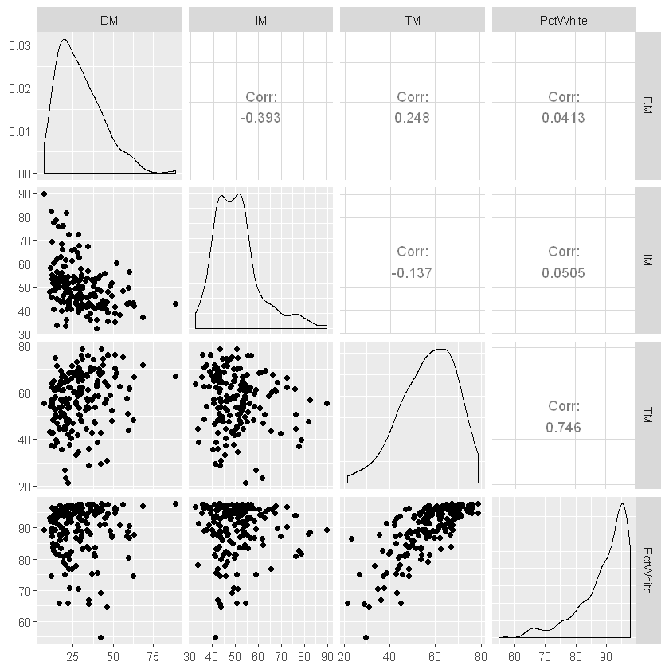

```r
ggpairs(dfw)
```

ggpairs plot observations:

Skewness:

• The Explanatory variable PctWhite (Percentage of White population) is extremely left skewed. This implies that most of the counties are majorly white populated.

• The Death rate and Income are fairly right skewed. This can be easily understood since the death rates are going to relative smaller values.

Outliers:

The graph between Income and Trump percentage has a fair number of outliers. There are a few counties which irrespective of the incomes are either extreme supporters of Trump or extreme haters of Trump.

Multicollinearity:

It can be observed from the graph between Percentage of white population and Trump supporters that there is clearly a linear trend. With increasing percentage of white population in a county, the support for trump increases.

High Correlation:

Among all the variable, there exists a strong correlation only between Trump and PctWhite variable.

# Q 2

We are taking Trump as a variable for our model since PCTWhite values are left skewed.

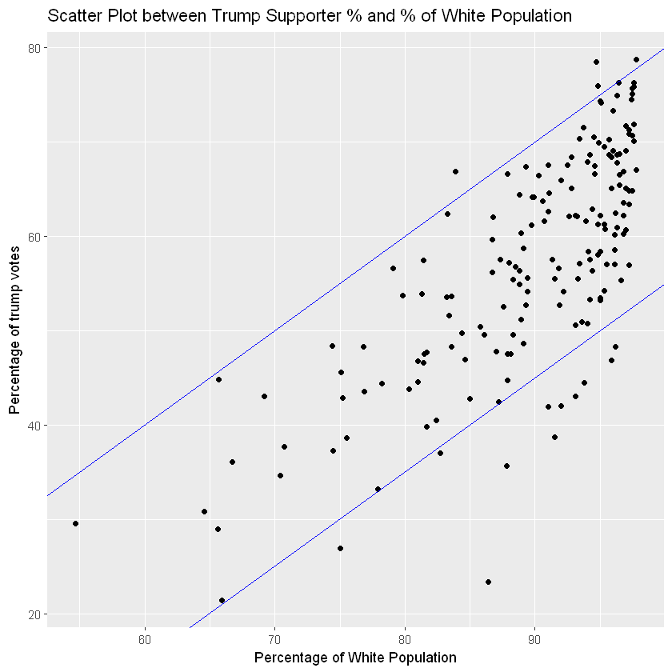

```r
ggplot(dfw, aes(y= TM, x=PctWhite)) + geom_point() +
  geom_abline(intercept = -20 , slope = 1, color = "blue") +
  geom_abline(intercept = -45 , slope = 1, color = "blue") +
ggtitle("Scatter Plot between Trump Supporter % and % of White Population") + ylab("Percentage of trump votes") +
xlab("Percentage of White Population")
```

It can be observed from the ggpairs graph that there is a strong correlation of 0.746 between Trump and Percentage of White population. Hence we choose Trump from the two as explanatory variable for the response variable.

We are taking Trump as a variable for our model since PCTWhite values are left skewed.

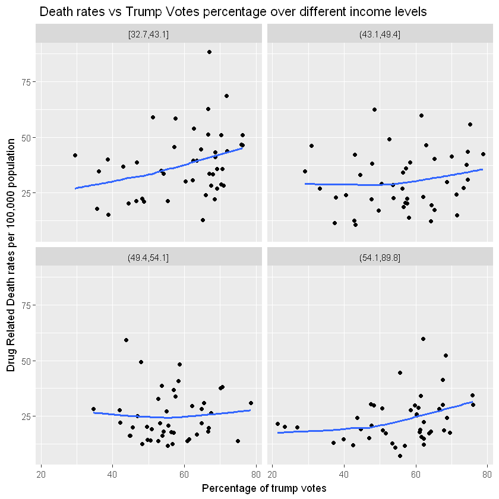

```r
ggplot(dfw, aes(y= DM, x=TM)) + geom_point() +
  geom_smooth(span = 1,formula = y ~ x, method.args = list(degree = 1),se = FALSE) +
  facet_wrap(~cut_number(IM, n =4)) +
  ggtitle(" Death rates vs Trump Votes percentage over different income levels")+
  ylab("Drug Related Death rates per 100,000 population ") +
  xlab("Percentage of trump votes")
```

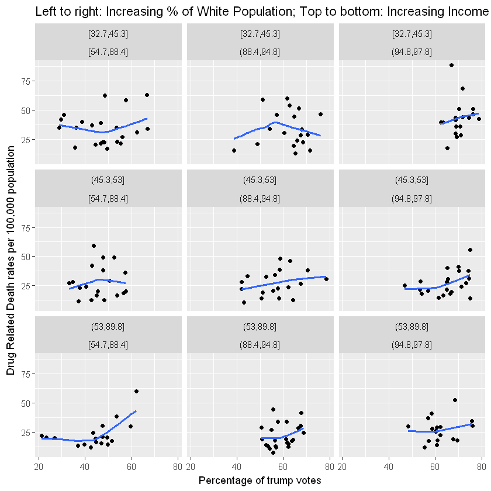

```r
ggplot(dfw, aes(y= DM, x=TM)) + geom_point() +
  geom_smooth(span = 1,formula = y ~ x, method.args = list(degree = 1),se = FALSE) +
  facet_wrap(~cut_number(IM, n =3) + ~cut_number(PctWhite, n =3)) +
  ggtitle("Left to right: Increasing % of White Population; Top to bottom: Increasing Income")+
  ylab("Drug Related Death rates per 100,000 population ") +
  xlab("Percentage of trump votes")
```

We can observe that the one-way faceted plot follows a particular trend of Death Rate and the two-way faceted plot does not have any particular trend for building a model. So, we consider only one-way faceted plot.

Hence Income and Trump interaction is needed to explain our model

From the one-way faceted plot we may say that death rate is increasing with Percent of votes for Trump. But we need to fit a model to confirm this trend.

# Q 3

```r
attach(dfw)
dfw.lm = lm(DM ~ IM*TM)
lm.grid = expand.grid(TM= min(TM):max(TM), IM= c(33,43,50,54,65,70) )
DM.predict = predict(dfw.lm,lm.grid)
df.DM = data.frame(lm.grid, fit = as.vector(DM.predict))
```

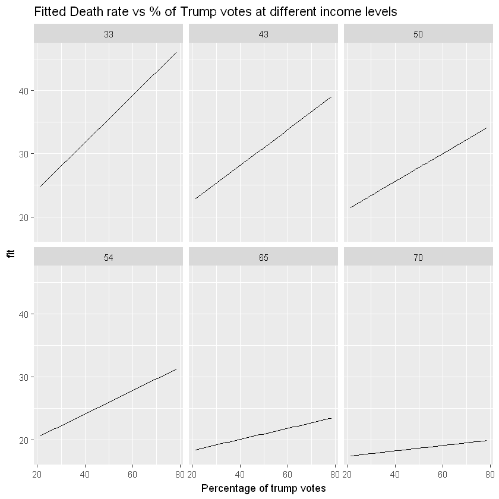

```r
ggplot(df.DM, aes(y= fit, x= TM)) + geom_line() + facet_wrap(~IM, drop = FALSE)+
  xlab("Percentage of trump votes")+
  ggtitle("Fitted Death rate vs % of Trump votes at different income levels")
```

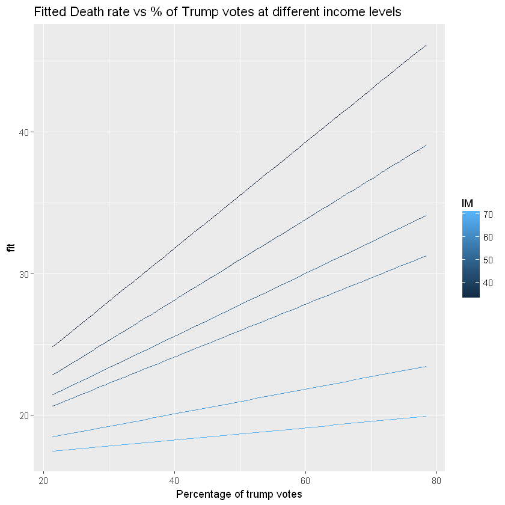

```r
ggplot(df.DM, aes(y= fit, x= TM, group = IM,color = IM)) +
  geom_line() +xlab("Percentage of trump votes")+
  xlab("Percentage of trump votes")+
  ggtitle("Fitted Death rate vs % of Trump votes at different income levels")
```